# STATS 762 - Assignment 3 - model answers

```r
library(glmnet); library(grpreg); library(quantreg); library(pscl); library(MASS)
```

# Question 1

The data is loaded and a zero-inflated Poisson regression is fitted.

```r
bike = read.csv(file='bikesharing.csv',header=TRUE)
bike$weather_code=as.factor(bike$weather_code)
zinf1 <- zeroinfl(cnt~t2+weather_code+is_weekend,data=bike,dist='poisson')
zinf1
```

```
##
## Call:
## zeroinfl(formula = cnt ~ t2 + weather_code + is_weekend, data = bike,
##     dist = "poisson")
##
## Count model coefficients (poisson with log link):
##    (Intercept)              t2   weather_code2   weather_code3   weather_code4
##        1.94207         0.01074         0.12759         0.10556        -0.12868
##  weather_code7  weather_code26      is_weekend
##       -0.43110        -0.27934        -0.54776
##
## Zero-inflation model coefficients (binomial with logit link):
##    (Intercept)              t2   weather_code2   weather_code3   weather_code4
##       -0.84203        -0.08761        -0.67775        -0.41983         0.71461
##  weather_code7  weather_code26      is_weekend
##        0.34796         1.06518        -0.44448
```

### (a)

```r
p1=predict(zinf1,data.frame(is_weekend=0,weather_code="7",t2=12.5),type='zero')
p1+(1-p1)*
dpois(0,predict(zinf1,data.frame(is_weekend=0,weather_code="7",t2=12.5),type='count') )
```

```
##        1
## 0.174167
```

### (b)

```r
predict(zinf1,data.frame(is_weekend=1,weather_code="1",t2=11.3),type='response')
```

```
##        1
## 4.128706
```

### (c)

A probability for zero inflation is characterized from coefficient estimates. A probability for zero inflation increases as a temperature decreases and will reach the max on any coldest snowy weekday. A probability of zero count is a summation of probabilities for zero-inflation and Poisson model at 0 and, the question is whether a probability for zero sharing is dominated by a probability for zero inflation for this data.

There are two ways in computing a probability for zero count using the prediction-function. For example, we want to get a probability for a clear Sunday, 11.3C.

```r
#lambda for a Poisson model
lambda <- predict(zinf1,data.frame(is_weekend=1,t2=11.3,weather_code='1'),type='count')
#prob for zero-inflation
p.zeroinfl <- predict(zinf1,data.frame(is_weekend=1,t2=11.3,weather_code='1'),type='zero')
#zero prob
p.zeroinfl+(1-p.zeroinfl)*dpois(0,lambda)
```

```
##        1
## 0.102651
```

```r
#Alternatively
predict(zinf1,data.frame(is_weekend=1,t2=11.3,weather_code='1'),type='prob')[1]
```

```
## [1] 0.102651
```

Let’s plot probabilities for zero sharing with the three information (weekend/t2/weather code).

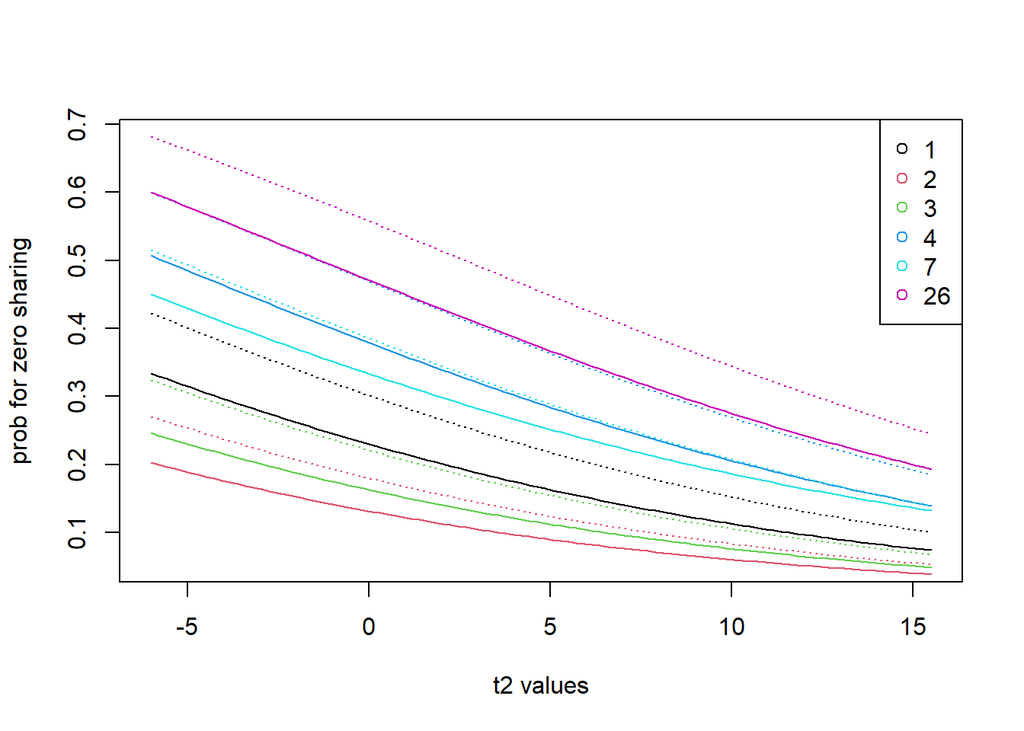

```r
t <- seq(from=-6.0,to=15.5,length.out=100)
lambda = lambda.wknd = p.zero = p.zero.wknd = matrix(0,6,length(t))
code=c("1","2","3","4","7","26")
for(i in 1:6){
  lambda.wknd[i,] <- predict(zinf1,data.frame(t2=t,is_weekend=1,weather_code=code[i]),type='count')
  lambda[i,] <- predict(zinf1,data.frame(t2=t,is_weekend=0,weather_code=code[i]),type='count')
  p.zero.wknd[i,] <- predict(zinf1,data.frame(t2=t,is_weekend=1,weather_code=code[i]),type='zero')+(1-predict(zinf1,data.frame(t2=t,is_weekend=1,weather_code=code[i]),type='zero'))*dpois(0,lambda.wknd[i,])
  p.zero[i,] <- predict(zinf1,data.frame(t2=t,is_weekend=0,weather_code=code[i]),type='zero')+(1-predict(zinf1,data.frame(t2=t,is_weekend=0,weather_code=code[i]),type='zero'))*dpois(0,lambda[i,])
}

#Solid lines represent probabilities on weekends and dotted lines are for weekdays. Line color indicates a weather code.

plot(t,p.zero.wknd[1,],type='l',ylim=c(min(p.zero),max(p.zero)),ylab='prob for zero sharing',xlab='t2 values'); lines(t,p.zero[1,],lty=3)
lines(t,p.zero.wknd[2,],col=2); lines(t,p.zero[2,],lty=3,col=2)
lines(t,p.zero.wknd[3,],col=3); lines(t,p.zero[3,],lty=3,col=3)
lines(t,p.zero.wknd[4,],col=4); lines(t,p.zero[4,],lty=3,col=4)
lines(t,p.zero.wknd[5,],col=5); lines(t,p.zero[5,],lty=3,col=5)
lines(t,p.zero.wknd[6,],col=6); lines(t,p.zero[6,],lty=3,col=6)
legend('topright',pch=1,legend=code,col=c(1:6))
```

Solid lines represent probabilities on weekends and dotted lines are for weekdays. Line color indicates a weather code.

For all weather code and at every temperature, a higher probability is observed on weekdays. On snowy weekdays, as a temperature decreases, a probability for zero sharing increases and the max is obtained around -6 in this plot. Note that the max probability value and day description are not required.

### (d)

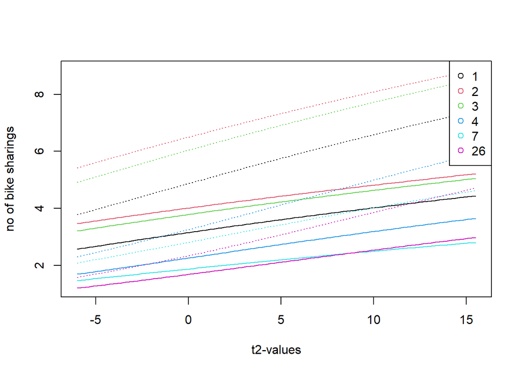

```r
t <- seq(from=-6.0,to=15.5,length.out=100)
x <- matrix(0,6,length(t))
x.wknd <- matrix(0,6,length(t))
code=c("1","2","3","4","7","26")
for(i in 1:6){
  x.wknd[i,] <- predict(zinf1,data.frame(t2=t,is_weekend=1,weather_code=code[i]),type='response')
  x[i,] <- predict(zinf1,data.frame(t2=t,is_weekend=0,weather_code=code[i]),type='response')
}

#Solid lines represent expected numbers on weekends and dotted lines are for weekdays. Line color indicates a weather code.
plot(t,x.wknd[1,],type='l',ylim=c(min(x.wknd),max(x)),ylab='no of bike sharings',xlab='t2-values'); lines(t,x[1,],lty=3)
lines(t,x.wknd[2,],col=2); lines(t,x[2,],lty=3,col=2)
lines(t,x.wknd[3,],col=3); lines(t,x[3,],lty=3,col=3)
lines(t,x.wknd[4,],col=4); lines(t,x[4,],lty=3,col=4)
lines(t,x.wknd[5,],col=5); lines(t,x[5,],lty=3,col=5)
lines(t,x.wknd[6,],col=6); lines(t,x[6,],lty=3,col=6)
legend('topright',pch=1,legend=code,col=c(1:6))
```

Solid lines represent expected numbers on weekends and dotted lines are for weekdays. Line color indicates a weather code.

Lower temperature on weekends tend to yield less bike sharing. Weather codes are in the order of Snowy day<Rainy day< Cloudy day< Sunny day<Broken clouds< scattered cloudy.

### (e)

Let’s plot the zero probabilities against temperatures for each weather condition.

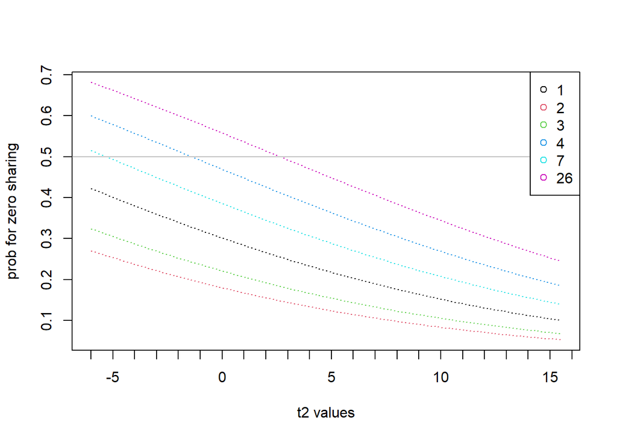

```r
plot(t,p.zero[1,],type='l',ylim=c(min(p.zero),max(p.zero)),ylab='prob for zero sharing',xlab='t2 values',lty=3);
lines(t,p.zero[2,],lty=3,col=2)
lines(t,p.zero[3,],lty=3,col=3)
lines(t,p.zero[4,],lty=3,col=4)
lines(t,p.zero[5,],lty=3,col=5)
lines(t,p.zero[6,],lty=3,col=6)
axis(side=1, at=seq(-6,16,by=1), labels = FALSE)
abline(h=0.5,col='grey')
legend('topright',pch=1,legend=code,col=c(1:6))
```

A snowy day with the temperature lower than 2.5C or a cloudy day with the temperature lower than -1.5C. Although it looks like a rainy day with the temperature lower than -5.5C seems like an ideal day, this prediction may not be precise because the historical temperature range is only (-3.0, 15.5). Note that these temperature values are read off from the figure and close values +/-0.3 will be accepted.

# Question 2

```r
air0 <- read.csv(file='Ashburton.csv',header=TRUE)
air0.Test <- read.csv(file='AshburtonTest.csv',header=TRUE)
```

### (a)

```r
sum(apply(air0,1,function(x) (sum(is.na(x))>0)))
```

```
## [1] 1032
```

```r
air1=air0[which(apply(air0,1,function(x) sum(is.na(x)))==0),]
```

1032 rows

### (b)

```r
sum(air1$PM10>50)
```

```
## [1] 99
```

99 rows

### (c)

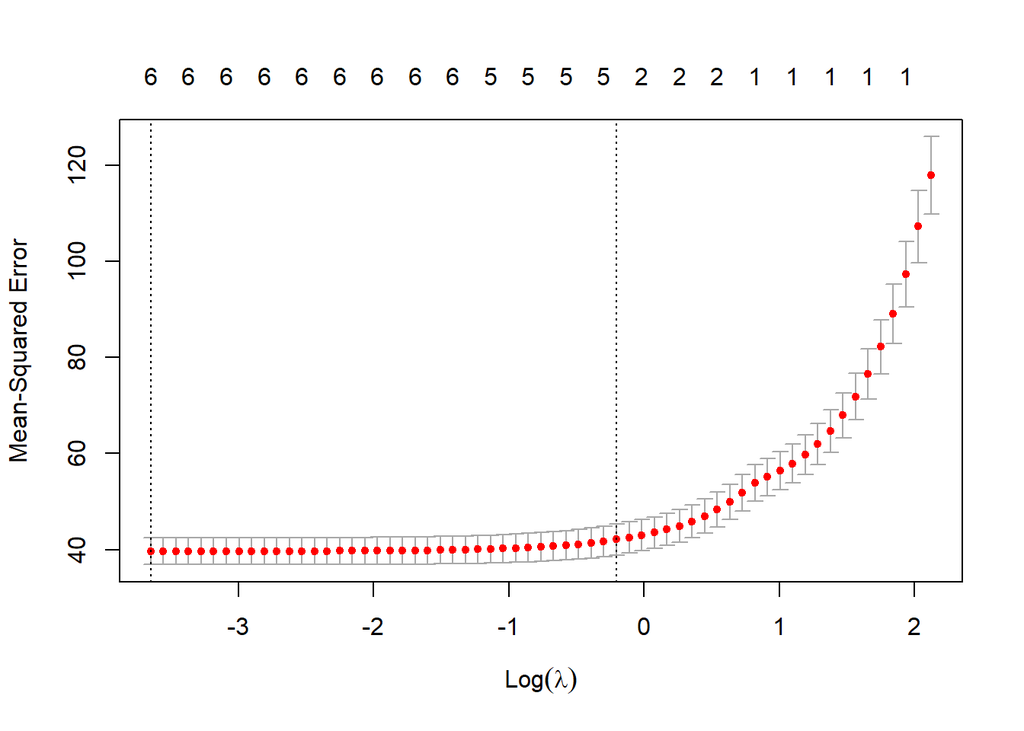

```r
set.seed(1234)
lasso.fit <- cv.glmnet(as.matrix(air1[,-2]),as.matrix(air1[,2]),alpha=1,standardize=TRUE)

plot(lasso.fit)
```

### (d)

```r
cbind(coef(lasso.fit,s=lasso.fit$lambda.min),coef(lasso.fit,s=lasso.fit$lambda.1se))
```

```
## 8 x 2 sparse Matrix of class "dgCMatrix"
##                             1            1
## (Intercept)       0.434560837  3.536323016
## Temp6m            0.191639712  0.332697297
## PM2.5             1.191573178  1.033020526
## WindSpeed         .            .
## Temp2m            0.233058131  0.001163152
## RelativeHumidity -0.018854450 -0.004248288
## WindDirection     0.002408358  .
## WindMax           0.270156209  0.017486995
```

### (e)

Sizes for the best and parsimonious models are different and, possible number of predicted values are different.

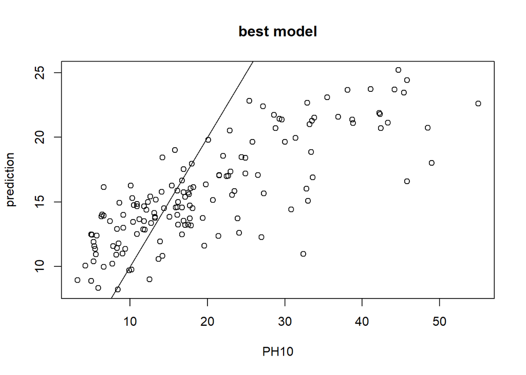

```r
#Let's find rows without missing values.
ii.best = which(apply(air0.Test[,-c(2,4)],1, function(x) sum(is.na(x)))==0)
ii.par = which(apply(air0.Test[,-c(2,4,7)],1, function(x) sum(is.na(x)))==0)

#prediction using the best model
pp1=predict(lasso.fit,as.matrix(air0.Test[ii.best,-2]),lambda=lasso.fit$lambda.min)
#prediction using the parsimmonious model
pp2=predict(lasso.fit,as.matrix(air0.Test[ii.par,-2]),s=lasso.fit$lambda.1se)

plot(air0.Test[ii.best,2],pp1,xlab='PH10',ylab='prediction',main='best model'); abline(coef = c(0,1))
```

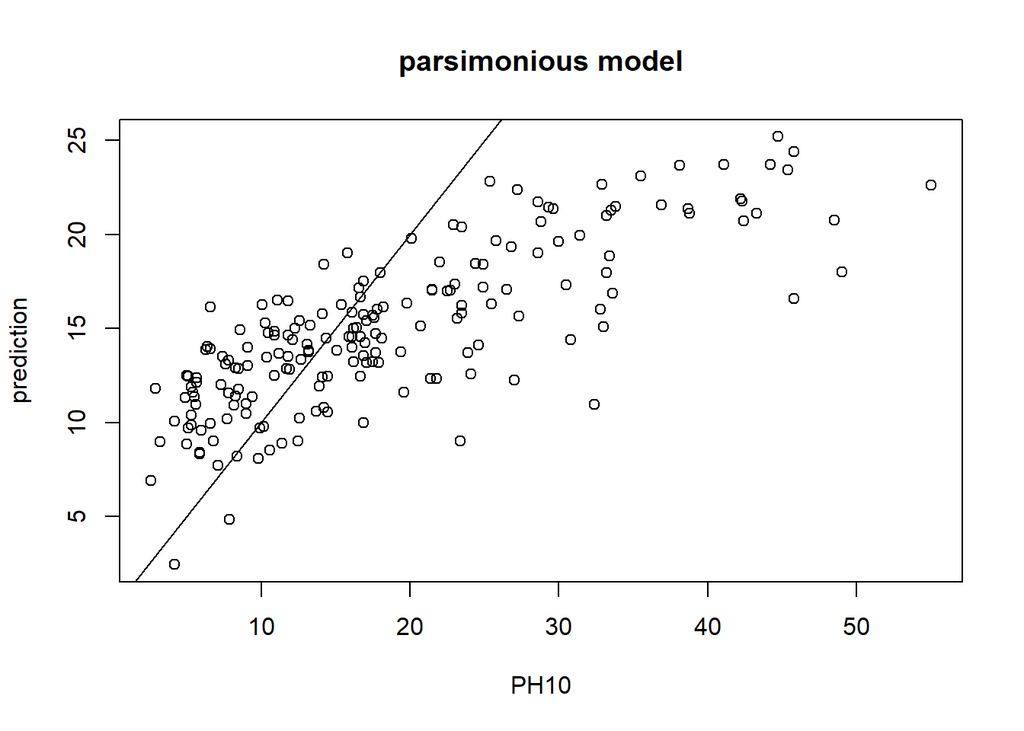

```r
plot(air0.Test[ii.par,2],pp2,xlab='PH10',ylab='prediction',main='parsimonious model'); abline(coef = c(0,1))
```

As it is seen in the figures, both models poorly predict high PM10 values.

### (f)

In a linear regression, important predictors are linear with the response variable. Among available predictors, PM2.5 is the most important one because of linearity to PM10 (a scatter plot or correlation will be enough for evidence). Higher coefficients can’t be the reason because of different ranges of predictors.

```r
#correlations as evidence
apply(air1[,-2],2,function(x) cor(x,air1[,2]))
```

```
##           Temp6m            PM2.5        WindSpeed           Temp2m
##      0.065449714      0.767218559     -0.043558821      0.049569191
## RelativeHumidity    WindDirection          WindMax
##     -0.069568386      0.003435534     -0.054076856
```

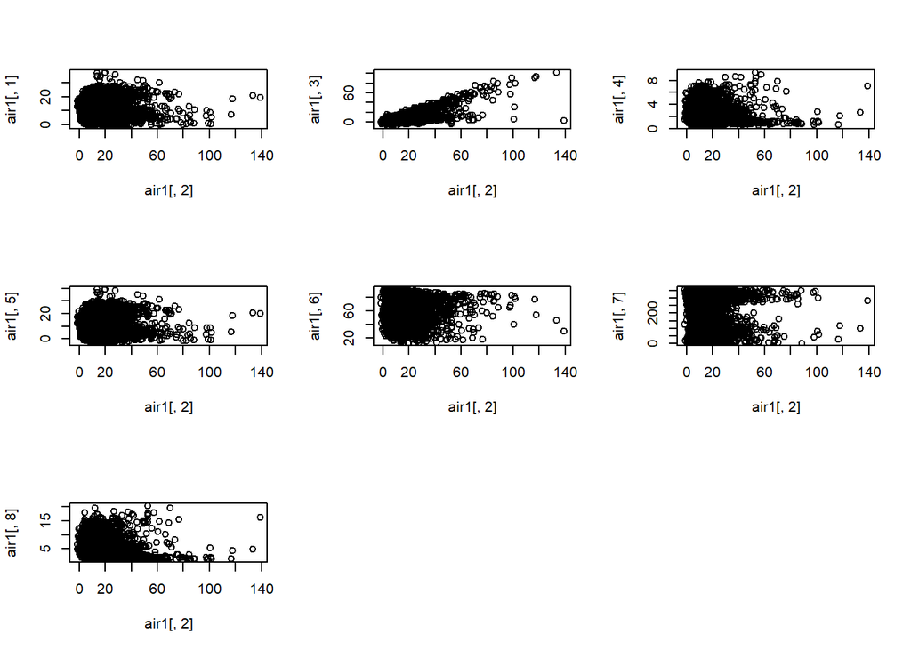

```r
#scatter plots
par(mfrow=c(3,3))
plot(air1[,2],air1[,1]); plot(air1[,2],air1[,3]); plot(air1[,2],air1[,4]); plot(air1[,2],air1[,5]); plot(air1[,2],air1[,6]); plot(air1[,2],air1[,7]);
plot(air1[,2],air1[,8])
```

An alternative approach is finding a predictor making big contribution in a linear regression model. If an important predictor is discarded from a model, this will increase a MSE (loss).

Note that the below is one example.

```r
set.seed(1234)
fit.Tem6m <- cv.glmnet(as.matrix(air1[,c(3:8)]),as.matrix(air1[,2]),alpha=1,standardize=TRUE)
mean((predict(fit.Tem6m,as.matrix(air1[,3:8]),s=fit.Tem6m$lambda.1se)-air1[,2])^2)
```

```
## [1] 41.97216
```

```r
fit.PM25 <- cv.glmnet(as.matrix(air1[,c(1,4:8)]),as.matrix(air1[,2]),alpha=1,standardize=TRUE)
mean((predict(fit.PM25,as.matrix(air1[,c(1,4:8)]),s=fit.PM25$lambda.1se)-air1[,2])^2)
```

```
## [1] 118.4915
```

```r
fit.WS <- cv.glmnet(as.matrix(air1[,c(1,3,5:8)]),as.matrix(air1[,2]),alpha=1,standardize=TRUE)
mean((predict(fit.WS,as.matrix(air1[,c(1,3,5:8)]),s=fit.WS$lambda.1se)-air1[,2])^2)
```

```
## [1] 41.96423
```

```r
fit.Tem2m <- cv.glmnet(as.matrix(air1[,c(1,3,4,6:8)]),as.matrix(air1[,2]),alpha=1,standardize=TRUE)
mean((predict(fit.Tem2m,as.matrix(air1[,c(1,3,4,6:8)]),s=fit.Tem2m$lambda.1se)-air1[,2])^2)
```

```
## [1] 44.04603
```

```r
fit.Humidity <- cv.glmnet(as.matrix(air1[,c(1,3:5,7,8)]),as.matrix(air1[,2]),alpha=1,standardize=TRUE)
mean((predict(fit.Humidity,as.matrix(air1[,c(1,3:5,7,8)]),s=fit.Humidity$lambda.1se)-air1[,2])^2)
```

```
## [1] 42.88253
```

```r
fit.WD <- cv.glmnet(as.matrix(air1[,c(1,3:6,8)]),as.matrix(air1[,2]),alpha=1,standardize=TRUE)
mean((predict(fit.WD,as.matrix(air1[,c(1,3:6,8)]),s=fit.WD$lambda.1se)-air1[,2])^2)
```

[output not shown]

```r
fit.WM <- cv.glmnet(as.matrix(air1[,c(1,3:7)]),as.matrix(air1[,2]),alpha=1,standardize=TRUE)
mean((predict(fit.WM,as.matrix(air1[,c(1,3:7)]),s=fit.WM$lambda.1se)-air1[,2])^2)
```

```
## [1] 42.01759
```

When PM2.5 was excluded, the largest MSE is obtained. Hence, PM2.5 is the most important variable.

# Question 3

Let $y,y'$ be a response variable (food expenditure) and $x$, independent variable (income). $Q$ and $Q'$ are objective functions associated with $q$-quantile regression for $y$ and $y'$ respectively.

$$Q=q\sum^n_{i:y_i\geq (a+x_i b)} |y_i-a-x_i b| +(1-q)\sum^n_{i:y_i< (a+x_i b)} |y_i-a-x_i b|$$
$$Q'=q\sum^n_{i:y'_i\geq (a'+x_i b')} |y'_i-a'-x_i b'| +(1-q)\sum^n_{i:y'_i< (a'+x_i b')} |y'_i-a'-x_i b'| \,.$$

Intercepts ($a,a'$) and coefficients ($b,b'$) are found by minimizing objective functions.
$$\hat{a},\hat{b} = argmin_{a,b} Q\,, \hspace{1cm} \hat{a}',\hat{b}' = argmin_{a',b'} Q'$$

Say $y_i'=y_i+c$. Substituting $y'=y+c$, $Q'$ becomes
$$Q' =q\sum^n_{i:y_i\geq (-c+a'+x_i b')} |y_i+c-a'-x_i b'| +(1-q)\sum^n_{i:y_i< (-c+a'+x_i b')} |y_i+c-a'-x_i b'|$$
and this equals to $Q$ if $b=b'$ and $a=-c+a'$.

Hence, if $(\hat{a},\hat{b})$ and $(\hat{a}',\hat{b}')$ minimize $Q$ and $Q'$ respectively then $\hat{a}'=\hat{a}+c$ and $\hat{b}'=\hat{b}$. The new quantile regression for $y'$ is shifted by $c$ from the quantile regression for $y$.